# 데이터 인코딩

## 1. 레이블 인코딩(Label encoding)

- Category형 변수의 값을 코드형 숫자 값으로 변환하는 것
- 예) TV:0, 냉장고:1, 믹서:2, 선풍기:3, 전자레인지:4, 컴퓨터:5

```python
import numpy as np
import pandas as pd
```

```python
items=['TV','냉장고','전자렌지','컴퓨터','선풍기','선풍기','믹서','믹서']
```

- **LabelEncoder의 객체(class instance) 생성 후, fit( ) 과 transform( ) 으로 label 인코딩**

```python
from sklearn.preprocessing import LabelEncoder
```

- **LabelEncoder의 객체 생성**

```python
encoder = LabelEncoder()
```

- **전체 데이터의 label 결정(학습)**

```python
encoder.fit(items)
```

- **변환(인코딩)**

```python
encoder.transform(items)
```

```python
labels=encoder.transform(items)
```

- **숫자 레이블을 원래 문자열을 매칭하고 싶다면 - inverse_transform**

```python
encoder.inverse_transform([4, 5, 2, 0, 1, 1, 3, 3])
```

### [주의!!]

- 레이블 인코딩 후 숫자값이 부여되므로 이를 머신러닝에 사용하는 경우, 예측 성능이 떨어질 수 있음
- 냉장고가 1, 믹서가2로 될 경우, 1보다 2가 크다는 의미가 부여되기 때문 (실제로는 단순한 구분용일 뿐)
- 이러한 이유로 레이블 인코딩은 회귀분석과 같은 머신러닝에서 사용하지 않아야 함
- 레이블 인코딩의 이러한 문제점을 해결하기 위한 방법이 바로 "원-핫 인코딩" 임!

## 2. 원-핫 인코딩(One-Hot encoding)

- feature값의 유형에 따라 새로운 feature를 추가해 고유값에 해당하는 column에만 1을 나머지 column에는 0을 부여하는 방법

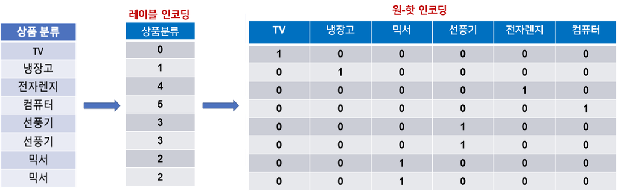

- **먼저 숫자값으로 변환을 위해 LabelEncoder을 실행**
- items=['TV','냉장고','전자렌지','컴퓨터','선풍기','선풍기','믹서','믹서']

```python
labels
```

- **원-핫 인코딩을 하는 간단한 방법 - pd.get_dummies()**

```python
import pandas as pd
```

- **item(딕셔너리 타입)으로 dataframe 생성하기**

```python
df = pd.DataFrame({'item':['TV','냉장고','전자렌지','컴퓨터','선풍기','선풍기','믹서','믹서'] })
df
```

```python
pd.get_dummies(df)
```